# Test a Perceptual Phenomenon

### Analyzing the Stroop Effect

(1) What is the independent variable? What is the dependent variable?

> **Independant variable:** the word condition congruent or congruent  
> **Dependant variable:** time taken to choose between the word conditions

(2) What is an appropriate set of hypotheses for this task? Specify your null and alternative hypotheses, and clearly define any notation used. Justify your choices.

(3) Report some descriptive statistics regarding this dataset. Include at least one measure of central tendency and at least one measure of variability. The name of the data file is 'stroopdata.csv'.

```python
import numpy as np
import pandas as pd
import matplotlib.pyplot as plt
%matplotlib inline

df = pd.read_csv('stroopdata.csv')
df.head()
```

|  | Congruent | Incongruent |
| --- | --- | --- |
| 0 | 12.079 | 19.278 |
| 1 | 16.791 | 18.741 |
| 2 | 9.564 | 21.214 |
| 3 | 8.630 | 15.687 |
| 4 | 14.669 | 22.803 |

```python
df.info()
```

```
<class 'pandas.core.frame.DataFrame'>
RangeIndex: 24 entries, 0 to 23
Data columns (total 2 columns):
Congruent      24 non-null float64
Incongruent    24 non-null float64
dtypes: float64(2)
memory usage: 464.0 bytes
```

> Getting congruent and incongruent mean and median to see which of them are higher

```python
df.Congruent.mean()
```

```
14.051124999999999
```

```python
df.Congruent.median()
```

```
14.3565
```

```python
df.Incongruent.mean()
```

```
22.015916666666666
```

```python
df.Incongruent.median()
```

```
21.017499999999998
```

```python
df.describe()
```

|  | Congruent | Incongruent |
| --- | --- | --- |
| count | 24.000000 | 24.000000 |
| mean | 14.051125 | 22.015917 |
| std | 3.559358 | 4.797057 |
| min | 8.630000 | 15.687000 |
| 25% | 11.895250 | 18.716750 |
| 50% | 14.356500 | 21.017500 |
| 75% | 16.200750 | 24.051500 |
| max | 22.328000 | 35.255000 |

```python
np.std(df, ddof=1)
```

```
Congruent      3.559358
Incongruent    4.797057
dtype: float64
```

```python
np.var(df)
```

```
Congruent      12.141153
Incongruent    22.052934
dtype: float64
```

> **From the numbers showing above we see that there is signficant difference in the time people take to read Incongruent words and Congruent words. The mean and median shows that Incongruent words takes people more time to read than Congruent by 8 seconds in average.**

(4) Provide one or two visualizations that show the distribution of the sample data. Write one or two sentences noting what you observe about the plot or plots.

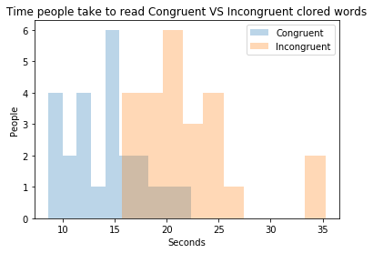

```python
plt.hist(df.Congruent, alpha= 0.3, label ='Congruent')
plt.hist(df.Incongruent, alpha= 0.3, label='Incongruent')
plt.title('Time people take to read Congruent VS Incongruent clored words')
plt.xlabel('Seconds')
plt.ylabel('People')
plt.legend()
```

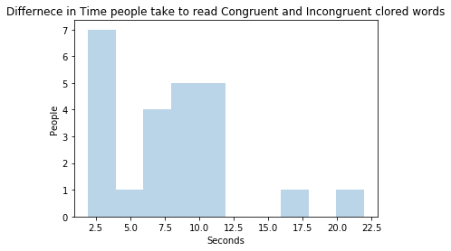

```python
plt.hist(df.Incongruent- df.Congruent, alpha= 0.3)
plt.title('Differnece in Time people take to read Congruent and Incongruent clored words')
plt.xlabel('Seconds')
plt.ylabel('People')
plt.legend()
```

> in the histogram above it shows that all people takes less time to finish reading Congruent words comparing to reading Incongruent words and most of people takes 2 to 12 seconds more to finish the Incongruent words reading.

(5) Now, perform the statistical test and report your results. What is your confidence level or Type I error associated with your test? What is your conclusion regarding the hypotheses you set up? Did the results match up with your expectations? **Hint:** Think about what is being measured on each individual, and what statistic best captures how an individual reacts in each environment.

```python
import scipy.stats as stats
stat, p_value = stats.ttest_rel(df.Incongruent, df.Congruent)
```

```python
p_value/2
```

```
2.0515002928555891e-08
```

```python
stat
```

```
8.020706944109957
```

(6) What do you think is responsible for the effects observed? Can you think of an alternative or similar task that would result in a similar effect? Some research about the problem will be helpful for thinking about these two questions!

It might happen for several reason and primarly practicing, someone who is reading this for the first time might get confused easily but someone who have done this thousands of times might not feel any difference.  
An example of similar case a baby might take 1 minute or more to walk for 10 meters while he can do the same in few seconds when he grow up.